# Breast cancer Literature Review

Bonface Onyango

2026-04-14

# Activate r_env

- Libraries installed in virtual r_env
- conda activate r_env

```r
# Core libraries
library(dplyr)
library(ggplot2)
library(igraph)
library(ggraph)
library(readr)
library(devtools)
```

## Install lisearch

```r
#uncomment or install in r env
#library(devtools)      # now should work
#install_github("elizagrames/litsearchr", ref="main")
```

```r
library(litsearchr)
```

## Litsearch version

```r
packageVersion("litsearchr")
```

```
[1] ‘1.0.0’
```

# Search query

- https://pubmed.ncbi.nlm.nih.gov/advanced/
- “breast cancer” AND (Algeria OR Angola OR Benin OR Botswana OR “Burkina Faso” OR Burundi OR “Cape Verde” OR Cameroon OR “Central African Republic” OR Chad OR Comoros OR “Democratic Republic of the Congo” OR “Republic of the Congo” OR Djibouti OR Egypt OR “Equatorial Guinea” OR Eritrea OR Eswatini OR Ethiopia OR Gabon OR Gambia OR Ghana OR Guinea OR “Guinea-Bissau” OR “Ivory Coast” OR Kenya OR Lesotho OR Liberia OR Libya OR Madagascar OR Malawi OR Mali OR Mauritania OR Mauritius OR Morocco OR Mozambique OR Namibia OR Niger OR Nigeria OR Rwanda OR “Sao Tome and Principe” OR Senegal OR Seychelles OR “Sierra Leone” OR Somalia OR “South Africa” OR “South Sudan” OR Sudan OR Tanzania OR Togo OR Tunisia OR Uganda OR Zambia OR Zimbabwe) AND (Europe* OR *America* OR Australia* ) AND (genetics OR environment OR healthcare) AND (incidence OR gene* OR clinical* OR treatment* OR and survival*)

## Loading and inspection of results

```r
df_pubmed<-import_results(file="../papers/pubmed-breastcanc-set.nbib")
```

```
Reading file ../papers/pubmed-breastcanc-set.nbib ... done
```

```r
df_pubmed <- as.data.frame(df_pubmed)
head(df_pubmed)
```

|  | publication_type | language | status | author | author_full | address | author_id | date_created | date_revised | date_completed | date_added | date_published_elec | date_published | publication_history_status | title | journal | journal_abbreviated | source | volume | issue | pages | abstract | mesh_terms | mesh_date | article_id | pubmed_id | nlm_id | place_published | copyright_info | … |
| --- | --- | --- | --- | --- | --- | --- | --- | --- | --- | --- | --- | --- | --- | --- | --- | --- | --- | --- | --- | --- | --- | --- | --- | --- | --- | --- | --- | --- | --- | --- |
| 1 |  | eng |  |  |  |  |  | 2025/02/24 23:37 | 20250530 |  | 2025/02/25 00:22 |  | 2025 Apr |  | Global patterns and trends in breast cancer incidence and mortality across 185 countries. |  | Nat Med |  |  |  |  |  |  | 2025/04/17 00:23 |  | 39994475 | 9502015 | United States |  | … |
| 2 |  | eng |  |  |  |  |  | 2018/02/16 06:00 | 20260302 |  | 2018/02/16 06:00 |  | 2018 May |  | Mutational spectrum in a worldwide study of 29,700 families with BRCA1 or BRCA2 mutations. |  | Hum Mutat |  |  |  |  |  |  | 2019/05/14 06:00 |  | 29446198 | 9215429 | United States |  | … |
| 3 |  | eng |  |  |  |  |  | 2022/01/14 05:54 | 20251212 |  | 2022/01/15 06:00 |  | 2022 Mar |  | Polygenic risk modeling for prediction of epithelial ovarian cancer risk. |  | Eur J Hum Genet |  |  |  |  |  |  | 2022/05/03 06:00 |  | 35027648 | 9302235 | England |  | … |
| 4 |  | eng |  |  |  |  |  | 2020/01/09 06:00 | 20250530 |  | 2020/01/09 06:00 |  | 2020 Jan |  | Fine-mapping of 150 breast cancer risk regions identifies 191 likely target genes. |  | Nat Genet |  |  |  |  |  |  | 2020/04/09 06:00 |  | 31911677 | 9216904 | United States |  | … |
| 5 |  | eng |  |  |  |  |  | 2019/12/05 06:00 | 20201022 |  | 2019/12/05 06:00 |  | 2019 Dec 14 |  | Sex differences in heart failure. |  | Eur Heart J |  |  |  |  |  |  | 2020/10/23 06:00 |  | 31800034 | 8006263 | England |  | … |
| 6 |  | eng |  |  |  |  |  | 2024/06/19 18:04 | 20260121 |  | 2024/06/20 00:42 |  | 2024 Aug |  | 6th and 7th International consensus guidelines for the management of advanced breast cancer (ABC guidelines 6 and 7). |  | Breast |  |  |  |  |  |  | 2024/07/19 00:41 |  | 38896983 | 9213011 | Netherlands |  | … |

## Number of articles -> 394

```r
nrow(df_pubmed)
```

```
[1] 394
```

```r
#We can take a look at the first few.
df_pubmed[1:3,]
```

|  | publication_type | language | status | author | author_full | address | author_id | date_created | date_revised | date_completed | date_added | date_published_elec | date_published | publication_history_status | title | journal | journal_abbreviated | source | volume | issue | pages | abstract | mesh_terms | mesh_date | article_id | pubmed_id | nlm_id | place_published | copyright_info | … |
| --- | --- | --- | --- | --- | --- | --- | --- | --- | --- | --- | --- | --- | --- | --- | --- | --- | --- | --- | --- | --- | --- | --- | --- | --- | --- | --- | --- | --- | --- | --- |
| 1 |  | eng |  |  |  |  |  | 2025/02/24 23:37 | 20250530 |  | 2025/02/25 00:22 |  | 2025 Apr |  | Global patterns and trends in breast cancer incidence and mortality across 185 countries. |  | Nat Med |  |  |  |  |  |  | 2025/04/17 00:23 |  | 39994475 | 9502015 | United States |  | … |
| 2 |  | eng |  |  |  |  |  | 2018/02/16 06:00 | 20260302 |  | 2018/02/16 06:00 |  | 2018 May |  | Mutational spectrum in a worldwide study of 29,700 families with BRCA1 or BRCA2 mutations. |  | Hum Mutat |  |  |  |  |  |  | 2019/05/14 06:00 |  | 29446198 | 9215429 | United States |  | … |
| 3 |  | eng |  |  |  |  |  | 2022/01/14 05:54 | 20251212 |  | 2022/01/15 06:00 |  | 2022 Mar |  | Polygenic risk modeling for prediction of epithelial ovarian cancer risk. |  | Eur J Hum Genet |  |  |  |  |  |  | 2022/05/03 06:00 |  | 35027648 | 9302235 | England |  | … |

## Column names

```r
# column names
colnames(df_pubmed)
```

```
 [1] "publication_type"           "language"                   "status"
 [4] "author"                     "author_full"                "address"
 [7] "author_id"                  "date_created"               "date_revised"
[10] "date_completed"             "date_added"                 "date_published_elec"
[13] "date_published"             "publication_history_status" "title"
[16] "journal"                    "journal_abbreviated"        "source"
[19] "volume"                     "issue"                      "pages"
[22] "abstract"                   "mesh_terms"                 "mesh_date"
[25] "article_id"                 "pubmed_id"                  "nlm_id"
[28] "place_published"            "copyright_info"             "grant_number"
[31] "location_id"                "subset"                     "cois"
[34] "own"                        "author_corporate"           "manuscript_id"
[37] "pubmed_central_identitfier" "pubmed_central_release"     "registry_number"
[40] "keywords"                   "term_owner_other"           "investigator"
[43] "investigator_full"          "ein"                        "cin"
[46] "secondary_source_id"        "other_id"                   "abstract_other"
[49] "oabl"                       "references_n"               "efr"
[52] "con"                        "rin"
```

```r
class(df_pubmed[1, "title"])
```

```
[1] "character"
```

```r
df_pubmed[1, "title"]
```

```
[1] "Global patterns and trends in breast cancer incidence and mortality across 185 countries."
```

```r
# KEYWORDS
# SOMme arrticles do not contain keywords like article 1
```

```r
df_pubmed[1, "keywords"]
```

```r
df_pubmed[2, "keywords"]
```

```
$`29446198`
[1] "BRCA1"          "BRCA2"          "breast cancer"  "ethnicity"      "geography"
[6] "mutation"       "ovarian cancer"
```

```r
# how many are missing keywords
# NULL → absence of a value or empty object → is.na() does not detect it.
is.null(df_pubmed[["keywords"]])     # checks if entire column is NULL
```

```
[1] FALSE
```

# Articles with no keywords ->193

```r
sum(sapply(df_pubmed$keywords, is.null))
```

```
[1] 193
```

# Extract keywords->tagged

```r
extract_terms(keywords=df_pubmed[, "keywords"], method="tagged")
```

```
 [1] "\"breast cancer\""                    "\"breast self-examination\""
 [3] "\"breast tumours\""                   "\"cell proliferation\""
 [5] "\"cervical cancer\""                  "\"chk2 inhibitors\""
 [7] "\"colorectal cancer\""                "\"coping strategies\""
 [9] "\"developing countries\""             "\"ductal carcinoma in situ\""
[11] "\"early detection\""                  "\"economic evaluation\""
[13] "\"extracellular matrix\""             "\"female thorax\""
[15] "\"financial toxicity\""               "\"genotoxic anticancer therapies\""
[17] "\"global disparities\""               "\"health equity\""
[19] "\"health literacy\""                  "\"healthcare disparities\""
[21] "\"healthcare systems strengthening\"" "\"low-middle income countries\""
[23] "\"luminal breast cancer\""            "\"mammographic density\""
[25] "\"mammography positioning\""          "\"mendelian randomization\""
[27] "\"metastatic breast cancer\""         "\"molecular subtypes\""
[29] "\"next-generation sequencing\""       "\"north africa\""
[31] "\"ovarian cancer\""                   "\"overall survival\""
[33] "\"palliative care\""                  "\"pathogenic variants\""
[35] "\"patient survey\""                   "\"patient-centered care\""
[37] "\"personalized medicine\""            "\"policy framework\""
[39] "\"polygenic risk score\""             "\"precision medicine\""
[41] "\"progesterone receptor\""            "\"public health\""
[43] "\"quality of life\""                  "\"reproductive women\""
[45] "\"risk factors\""                     "\"secondary schools\""
[47] "\"south africa\""                     "\"sub-saharan africa\""
[49] "\"systematic review\""                "\"timely diagnosis\""
[51] "\"triple-negative breast cancer\""    "\"uterine cancer\""
[53] "\"whole exome sequencing\""           "\"women of african ancestry\""
[55] "c\"advanced breast cancer\""          "c\"african ancestry\""
[57] "c\"breast cancer\""                   "c\"breast tumours\""
[59] "middle-income countries\""
```

# Extract keywords -> cleaned

- The keywords had new lines and we had to reformat it before processding

```r
library(dplyr)
library(purrr)
library(dplyr)
library(purrr)
library(stringr)

clean_keywords <- function(x) {
  # Handle NULL or empty
  if (is.null(x) || length(x) == 0) return(character(0))

  # Remove NA
  x <- x[!is.na(x)]
  if (length(x) == 0) return(character(0))

  # Clean and split
  x %>%
    str_replace_all("\\n", " ") %>%     # remove newlines
    str_replace_all("\"", "") %>%       # remove quotes
    str_trim() %>%                      # trim whitespace
    str_split(",") %>%                  # split by comma
    unlist() %>%                        # flatten
    str_trim() %>%                      # trim again
    discard(~ .x %in% c("", "NULL", "character0"))
}

# Apply to df_pubmed$keywords and flatten
df_pubmed <- df_pubmed %>%
  mutate(keywords_clean = map(keywords, clean_keywords))

# Flatten all keywords
keywords_flat <- df_pubmed$keywords_clean %>%
  flatten_chr()

# Remove empty
keywords_flat <- keywords_flat[keywords_flat != ""]
keywords_flat[1:5]
```

```
[1] "BRCA1"         "BRCA2"         "breast cancer" "ethnicity"     "geography"
```

```r
# Preview
```

## Tagged keywords

```r
keywords_extracted <- extract_terms(
  keywords = keywords_flat,
  method = "tagged"
)

# --- Step 4: Preview ---
keywords_extracted[1:20]
```

```
 [1] "adjuvant therapy"         "advanced breast cancer"   "african ancestry"
 [4] "breast cancer"            "breast self-examination"  "breast tumours"
 [7] "cancer genetics"          "cell proliferation"       "cervical cancer"
[10] "chk2 inhibitors"          "colorectal cancer"        "coping strategies"
[13] "developing countries"     "ductal carcinoma in situ" "early detection"
[16] "economic evaluation"      "extracellular matrix"     "female thorax"
[19] "financial toxicity"       "gene expression"
```

## Tagged keywords -> with >=1 word -> 117

```r
print(length(keywords_extracted_min_1))
```

```
[1] 117
```

```r
keywords_extracted <- extract_terms(
  keywords = keywords_flat,
  method = "tagged",
  min_n = 2
)

print(length(keywords_extracted))
```

```
[1] 60
```

```r
keywords_extracted[1:20]
```

```
 [1] "adjuvant therapy"         "advanced breast cancer"   "african ancestry"
 [4] "breast cancer"            "breast self-examination"  "breast tumours"
 [7] "cancer genetics"          "cell proliferation"       "cervical cancer"
[10] "chk2 inhibitors"          "colorectal cancer"        "coping strategies"
[13] "developing countries"     "ductal carcinoma in situ" "early detection"
[16] "economic evaluation"      "extracellular matrix"     "female thorax"
[19] "financial toxicity"       "gene expression"
```

# Tittle search ->105

```r
terms <- extract_terms(
  text = df_pubmed[, "title"],
  method = "fakerake",
  min_freq = 3,
  min_n = 2
)

length(terms)
```

```
[1] 105
```

# Stop words

```r
clinpsy_stopwords <- read_lines("../papers/clin_psy_stopwords.txt")

print(length(clinpsy_stopwords))
```

```
[1] 127
```

```r
clinpsy_stopwords
```

```
  [1] "advances"        "analyse"         "analysed"        "analyses"        "analysing"
  [6] "analysis"        "analyze"         "analyzes"        "analyzed"        "analyzing"
 [11] "assess"          "assessed"        "assesses"        "assessing"       "assessment"
 [16] "assessments"     "benefit"         "based"           "benefits"        "change"
 [21] "changed"         "changes"         "changing"        "characteristic"  "characteristics"
 [26] "characterize"    "characterized"   "characterizes"   "characterizing"  "clinical"
 [31] "cluster"         "combine"         "combined"        "combines"        "combining"
 [36] "comorbid"        "comorbidity"     "compare"         "compared"        "compares"
 [41] "comparing"       "comparison"      "control"         "controlled"      "controlling"
 [46] "controls"        "design"          "designed"        "designing"       "effect"
 [51] "effective"       "effectiveness"   "effects"         "efficacy"        "feasible"
 [56] "feasibility"     "follow"          "followed"        "following"       "follows"
 [61] "group"           "groups"          "impact"          "intervention"    "interventions"
 [66] "longitudinal"    "moderate"        "moderated"       "moderates"       "moderating"
 [71] "moderator"       "moderators"      "outcome"         "outcomes"        "patient"
 [76] "patients"        "people"          "pilot"           "practice"        "predict"
 [81] "predicted"       "predicting"      "predictor"       "predictors"      "predicts"
 [86] "preliminary"     "primary"         "protocol"        "quality"         "random"
 [91] "randomise"       "randomised"      "randomising"     "randomize"       "randomized"
 [96] "randomizing"     "rationale"       "reduce"          "reduced"         "reduces"
[101] "reducing"        "related"         "report"          "reported"        "reporting"
[106] "reports"         "response"        "responses"       "result"          "resulted"
[111] "resulting"       "results"         "review"          "studied"         "studies"
[116] "study"           "studying"        "systematic"      "treat"           "treated"
[121] "treating"        "treatment"       "treatments"      "treats"          "trial"
[126] "trials"          "versus"
```

```r
# english stop words
get_stopwords("English")
```

```
  [1] "a"             "a's"           "able"          "about"         "above"
  [6] "according"     "accordingly"   "across"        "actually"      "after"
 [11] "afterwards"    "again"         "against"       "ain't"         "all"
 [16] "allow"         "allows"        "almost"        "alone"         "along"
 [21] "already"       "also"          "although"      "always"        "am"
 [26] "among"         "amongst"       "an"            "and"           "another"
 [31] "any"           "anybody"       "anyhow"        "anyone"        "anything"
 [36] "anyway"        "anyways"       "anywhere"      "apart"         "appear"
 [41] "appreciate"    "appropriate"   "are"           "aren't"        "around"
 [46] "as"            "aside"         "ask"           "asking"        "associated"
 [51] "at"            "available"     "away"          "awfully"       "b"
 [56] "be"            "became"        "because"       "become"        "becomes"
 [61] "becoming"      "been"          "before"        "beforehand"    "behind"
 [66] "being"         "believe"       "below"         "beside"        "besides"
 [71] "best"          "better"        "between"       "beyond"        "both"
```

[output cut: 100 more lines]

```r
cat("Number of stopwords:", length(get_stopwords("English")), "\n")
```

```
Number of stopwords: 571
```

```r
all_stopwords <- c(get_stopwords("English"), clinpsy_stopwords)
print(length(all_stopwords))
```

```
[1] 698
```

```r
head(all_stopwords, 10)
```

```
 [1] "a"           "a's"         "able"        "about"       "above"       "according"
 [7] "accordingly" "across"      "actually"    "after"
```

# Keywords from tittle after removing stop words ->78

```r
title_terms <- extract_terms(
text=df_pubmed[, "title"],
method="fakerake",
min_freq=3, min_n=2,
stopwords=all_stopwords
)
print(length(title_terms))
```

```
[1] 78
```

```r
head(title_terms,10)
```

```
 [1] "advanced breast"         "advanced breast cancer"  "african american"
 [4] "african ancestry"        "african breast"          "african women"
 [7] "biomarker working"       "brca2 mutation"          "brca2 mutation carriers"
[10] "brca2 mutations"
```

## Keywords + title terms ->181

```r
terms <- unique(c(keywords_extracted_min_1, title_terms))
print(length(terms))
```

```
[1] 181
```

```r
head(terms,10)
```

```
 [1] "3-f"                    "adjuvant therapy"       "advanced breast cancer"
 [4] "africa"                 "african"                "african ancestry"
 [7] "apoptosis"              "bi-rads"                "biomarker"
[10] "brca"
```

# Network analysis

```r
docs <- paste(df_pubmed[, "title"], df_pubmed[, "keywords"])
docs[4]
```

```
[1] "Fine-mapping of 150 breast cancer risk regions identifies 191 likely target genes. NULL"
```

```r
dfm <- create_dfm(elements=docs, features=terms)
dfm[1:5, 1:7]
```

```
     3-f adjuvant therapy advanced breast cancer africa african african ancestry apoptosis
[1,]   0                0                      0      0       0                0         0
[2,]   0                0                      0      0       0                0         0
[3,]   0                0                      0      1       1                0         0
[4,]   0                0                      0      0       0                0         1
[5,]   0                0                      0      0       0                0         0
```

```r
g <- create_network(dfm, min_studies=3)
```

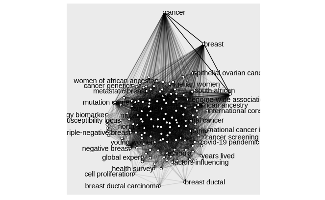

```r
ggraph(g, layout="stress") +
coord_fixed() +
expand_limits(x=c(-3, 3)) +
geom_edge_link(aes(alpha=weight)) +
geom_node_point(shape="circle filled", fill="white") +
geom_node_text(aes(label=name), hjust="outward", check_overlap=TRUE) +
guides(edge_alpha=FALSE)
```

```r
strengths <- strength(g)
data.frame(term=names(strengths), strength=strengths, row.names=NULL) %>%
mutate(rank=rank(strength, ties.method="min")) %>%
arrange(strength) ->
term_strengths
term_strengths
```

| term | strength | rank |
| --- | --- | --- |
| timely diagnosis | 21 | 1 |
| adjuvant therapy | 22 | 2 |
| patient survey | 22 | 2 |
| mendelian randomisation | 25 | 4 |
| mendelian randomization | 29 | 5 |
| reimbursement | 29 | 5 |
| immunotherapy | 31 | 7 |
| international consensus | 31 | 7 |
| financial toxicity | 32 | 9 |
| cell proliferation | 34 | 10 |

[output cut: 146 more lines]

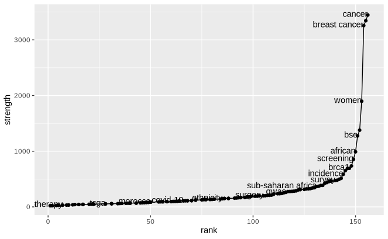

```r
cutoff_fig <- ggplot(term_strengths, aes(x=rank, y=strength, label=term)) +
geom_line() +
geom_point() +
geom_text(data=filter(term_strengths, rank>5), hjust="right", nudge_y=20,
check_overlap=TRUE)
cutoff_fig
```

```r
cutoff_cum <- find_cutoff(g, method="cumulative", percent=0.8)
cutoff_cum
```

```
[1] 181
```

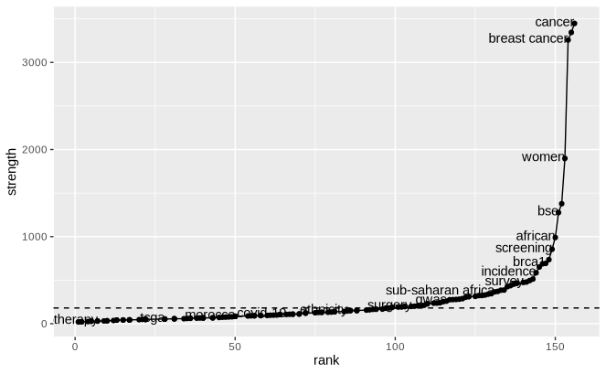

```r
cutoff_fig +
geom_hline(yintercept=cutoff_cum, linetype="dashed")
```

```r
get_keywords(reduce_graph(g, cutoff_cum))
```

```
 [1] "africa"                        "african"                       "african ancestry"              "biomarker"                     "brca"                          "brca1"
 [7] "brca2"                         "breast"                        "breast cancer"                 "bse"                           "cancer"                        "cervical cancer"
[13] "determinants"                  "early detection"               "egypt"                         "gene expression"               "guidelines"                    "gwas"
[19] "her2"                          "incidence"                     "intervention"                  "knowledge"                     "low-income"                    "middle-income countries"
[25] "mutation"                      "ovarian cancer"                "pathogenic variants"           "phenotype"                     "polygenic risk score"          "practice"
[31] "prevention"                    "progesterone receptor"         "prognosis"                     "public health"                 "risk factors"                  "screening"
[37] "sub-saharan africa"            "surgery"                       "survey"                        "synthesis"                     "systematic review"             "triple-negative breast cancer"
[43] "women"                         "women of african ancestry"     "african american"              "brca2 mutation"                "breast cancer screening"       "breast cancers"
[49] "cancer incidence"              "cancer screening"              "cancer susceptibility"         "european ancestry"             "genetic variants"              "genome-wide association"
[55] "mutation carriers"             "national cancer"               "negative breast"               "negative breast cancer"        "triple-negative breast"
```

```r
cutoff_change <- find_cutoff(g, method="changepoint", knot_num=3)
cutoff_change
```

```
[1]  387  855 1378 3447
```

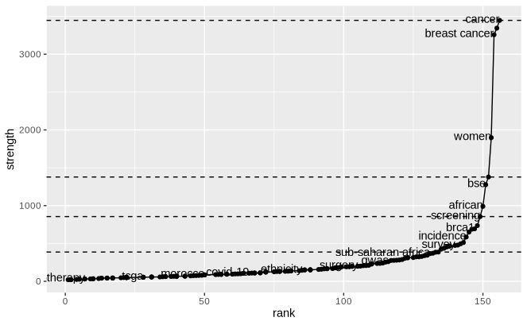

```r
cutoff_fig +
geom_hline(yintercept=cutoff_change, linetype="dashed")
```

```r
g_redux <- reduce_graph(g, cutoff_change[1])
selected_terms <- get_keywords(g_redux)
selected_terms
```

```
 [1] "africa"                 "african"                "brca"                   "brca1"                  "brca2"                  "breast"                 "breast cancer"          "bse"
 [9] "cancer"                 "her2"                   "incidence"              "intervention"           "knowledge"              "mutation"               "practice"               "prevention"
[17] "risk factors"           "screening"              "survey"                 "women"                  "cancer screening"       "negative breast"        "negative breast cancer"
```

```r
extra_terms <- c(
"medication",
"cognitive-behavioural therapy",
"cognitive behavioural therapy"
)
selected_terms <- c(selected_terms, extra_terms)
selected_terms
```

```
 [1] "africa"                        "african"                       "brca"                          "brca1"                         "brca2"                         "breast"
 [7] "breast cancer"                 "bse"                           "cancer"                        "her2"                          "incidence"                     "intervention"
[13] "knowledge"                     "mutation"                      "practice"                      "prevention"                    "risk factors"                  "screening"
[19] "survey"                        "women"                         "cancer screening"              "negative breast"               "negative breast cancer"        "medication"
[25] "cognitive-behavioural therapy" "cognitive behavioural therapy"
```